# Recommender System

Avnish

30/04/2020

# Introduction

We are building a movie recommender system using open source database *10M version of the MovieLens dataset*. We have built multiple machine learning models to achieve maximum accuracy. This document will walk you through all the findings and how we have built different models and rationale behind it.

# Data Partition Test/validation

```r
library(tidyverse)
library(caret)
library(data.table)
library(recosystem)
library(lubridate)

dl <- tempfile()
download.file("http://files.grouplens.org/datasets/movielens/ml-10m.zip", dl)

ratings <- fread(text = gsub("::", "\t", readLines(unzip(dl, "ml-10M100K/ratings.dat"))),
                 col.names = c("userId", "movieId", "rating", "timestamp"))



movies <- str_split_fixed(readLines(unzip(dl, "ml-10M100K/movies.dat")), "\\::", 3)
colnames(movies) <- c("movieId", "title", "genres")
movies <- as.data.frame(movies) %>% mutate(movieId = as.numeric(levels(movieId))[movieId],title = as.character(title),genres = as.character(genres))

movielens <- left_join(ratings, movies, by = "movieId")

set.seed(1, sample.kind="Rounding")
test_index <- createDataPartition(y = movielens$rating, times = 1, p = 0.1, list = FALSE)
edx <- movielens[-test_index,]
temp <- movielens[test_index,]

validation <- temp %>%
  semi_join(edx, by = "movieId") %>%
  semi_join(edx, by = "userId")

removed <- anti_join(temp, validation)
edx <- rbind(edx, removed)

rm(dl, ratings, movies, test_index, temp, movielens, removed)
```

We will explore the rating distribution

```r
edx %>% group_by(rating) %>%
  summarize(count = n()) %>%
  arrange(desc(count))
```

```
## # A tibble: 10 x 2
##    rating   count
##     <dbl>   <int>
##  1    4   2588430
##  2    3   2121240
##  3    5   1390114
##  4    3.5  791624
##  5    2    711422
##  6    4.5  526736
##  7    1    345679
##  8    2.5  333010
##  9    1.5  106426
## 10    0.5   85374
```

# Variable transformation .

Exracting release year, rated year and adding 2 varibale releaseyear’and ‘ratedafter’.

```r
edx$timestamp=as.POSIXct(edx$timestamp, origin="1970-01-01")
edx$timestamp=format(as.Date(edx$timestamp, format="%d/%m/%Y"),"%Y")

release = str_sub(edx$title,start = -5,end = -2)
edx=edx%>%mutate(releaseyear=release)
rated=as.numeric(edx$timestamp)-as.numeric(edx$releaseyear)
edx=edx%>%mutate(ratedafter=rated)
```

Number of movies and users

```r
edx%>%summarize(users=length(unique(userId)),movies=length(unique(movieId)))
```

```
##   users movies
## 1 69878  10677
```

Plot Distribution of ratings

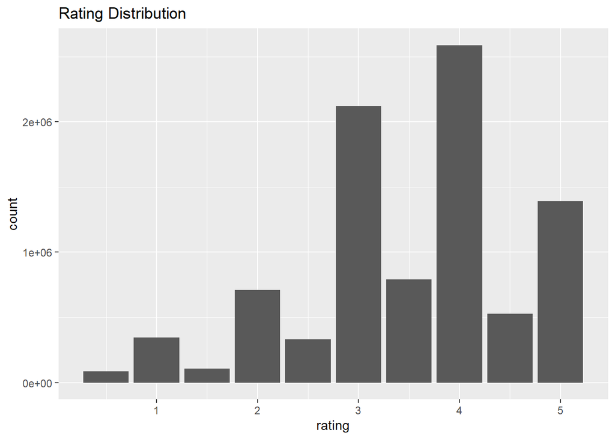

```r
edx%>%ggplot(aes(rating))+geom_bar()+ggtitle("Rating Distribution")
```

## Plot Distribution of users We see that there are users more more active than others.

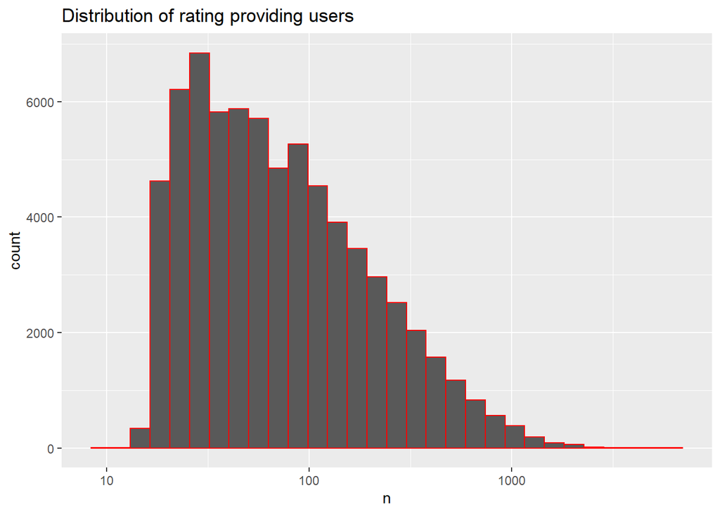

```r
edx%>%count(userId)%>%
 ggplot(aes(n))+geom_histogram(bins  = 30,color="red")+
  scale_x_log10()+ggtitle("Distribution of rating providing users")
```

## Distribution of no of times movie has been rated We see that some movies are watched/rated more than others.

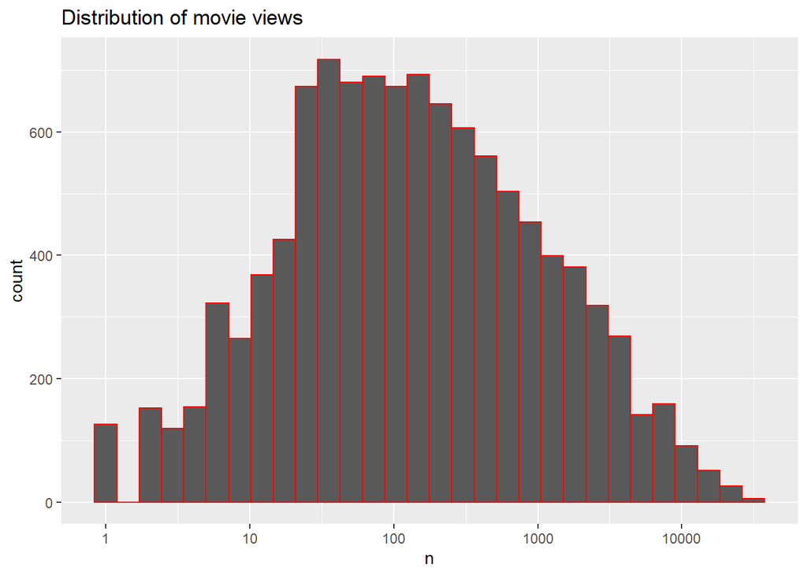

```r
edx%>%count(movieId,title)%>%
  ggplot(aes(n))+geom_histogram(bins=30,color="red")+
  scale_x_log10()+ggtitle("Distribution of movie views")
```

# Top 25 viewd movies

```r
head(edx%>%count(movieId,title)%>%arrange(desc(n))%>%select(title),25)
```

```
## # A tibble: 25 x 1
##    title
##    <chr>
##  1 Pulp Fiction (1994)
##  2 Forrest Gump (1994)
##  3 Silence of the Lambs, The (1991)
##  4 Jurassic Park (1993)
##  5 Shawshank Redemption, The (1994)
##  6 Braveheart (1995)
##  7 Fugitive, The (1993)
##  8 Terminator 2: Judgment Day (1991)
##  9 Star Wars: Episode IV - A New Hope (a.k.a. Star Wars) (1977)
## 10 Apollo 13 (1995)
## # ... with 15 more rows
```

## How average rating of movies varies for different movies

We see that some movies on average rated higher than others and vice-versa.

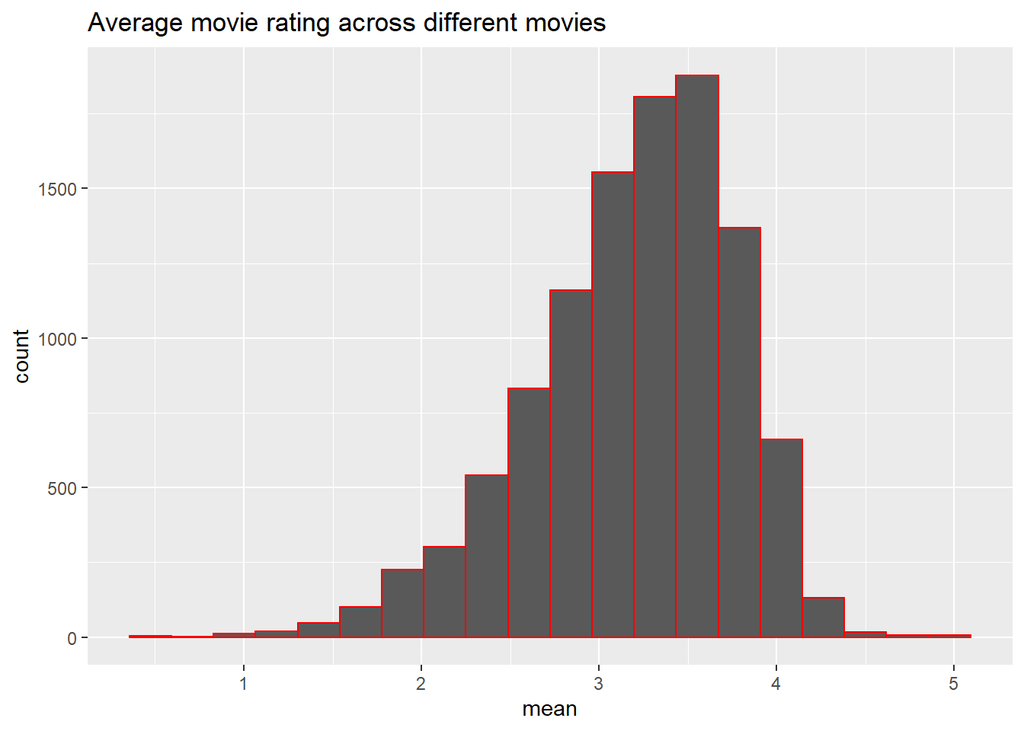

```r
edx%>%group_by(movieId)%>%summarise(mean=mean(rating))%>%ggplot(aes(mean))+geom_histogram(bins=20,color="red")+ggtitle("Average movie rating across different movies")
```

## How average rating of movies varies for different users

We see that some users on average tend to provide higher rating than other and vice-versa.

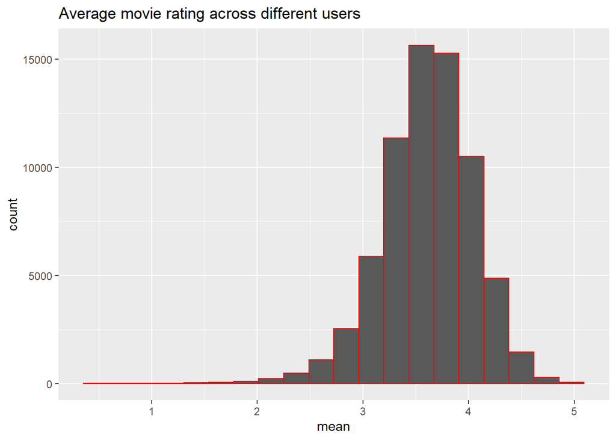

```r
edx%>%group_by(userId)%>%summarise(mean=mean(rating))%>%
  ggplot(aes(mean))+geom_histogram(bins=20,color="red")+ggtitle("Average movie rating across different users")
```

# How average rating of movies varies for different genres

Average rating also varies across different genre.

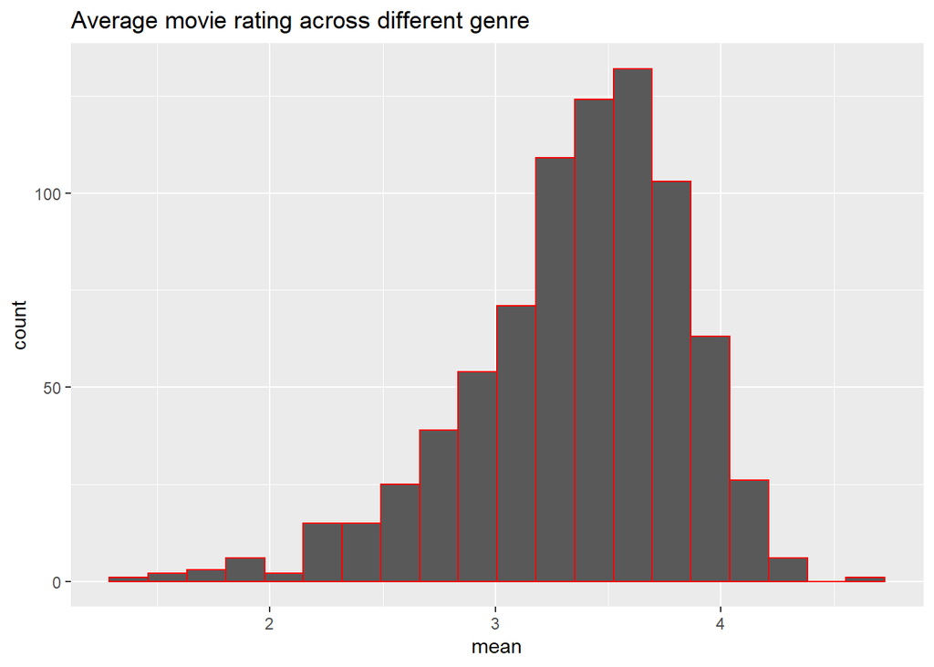

```r
edx%>%group_by(genres)%>%summarise(mean=mean(rating))%>%
  arrange(desc(mean))%>%
  ggplot(aes(mean))+geom_histogram(bins=20,color="red")+ggtitle("Average movie rating across different genre")
```

Top 25 rated genres

```r
head(edx%>%group_by(genres)%>%summarise(mean=mean(rating))%>%
       arrange(desc(mean)),25)
```

```
## # A tibble: 25 x 2
##    genres                                   mean
##    <chr>                                   <dbl>
##  1 Animation|IMAX|Sci-Fi                    4.71
##  2 Drama|Film-Noir|Romance                  4.30
##  3 Action|Crime|Drama|IMAX                  4.30
##  4 Animation|Children|Comedy|Crime          4.28
##  5 Film-Noir|Mystery                        4.24
##  6 Crime|Film-Noir|Mystery                  4.22
##  7 Film-Noir|Romance|Thriller               4.22
##  8 Crime|Film-Noir|Thriller                 4.21
##  9 Crime|Mystery|Thriller                   4.20
## 10 Action|Adventure|Comedy|Fantasy|Romance  4.20
## # ... with 15 more rows
```

## Relation between released year and average rating

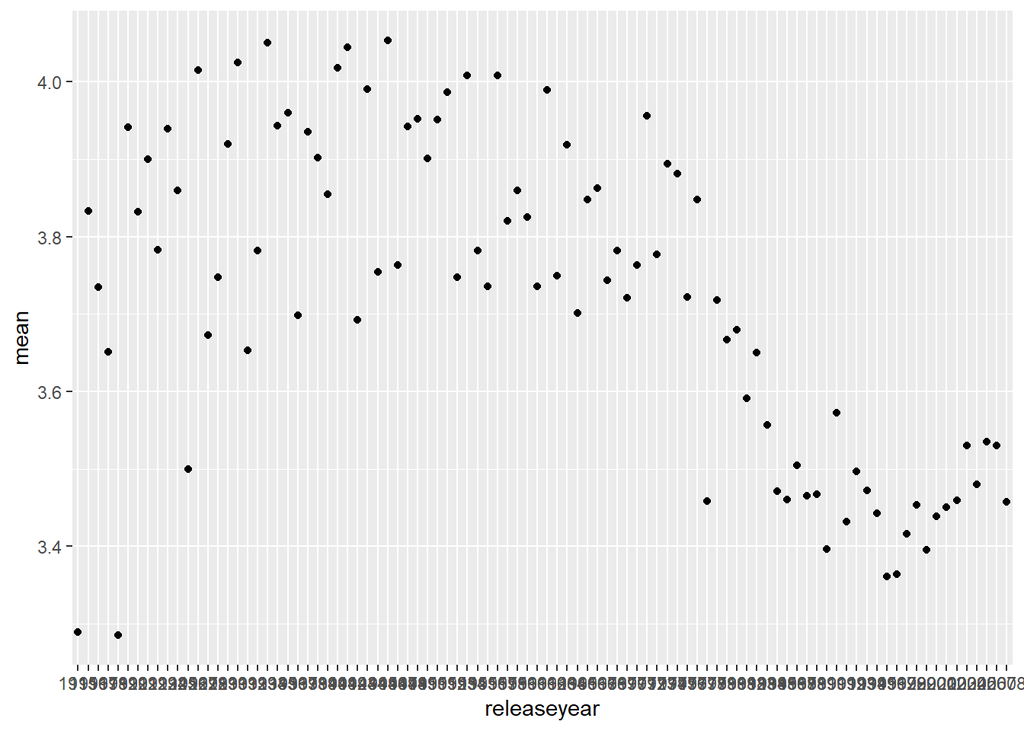

```r
edx%>%group_by(releaseyear)%>%summarise(mean=mean(rating))%>%
  ggplot(aes(releaseyear,mean))+geom_point()+geom_smooth()
```

## Relation between rated years after and average rating

How many years after the movies is being rated is also postively related . One of the possible reason will be classis movies.

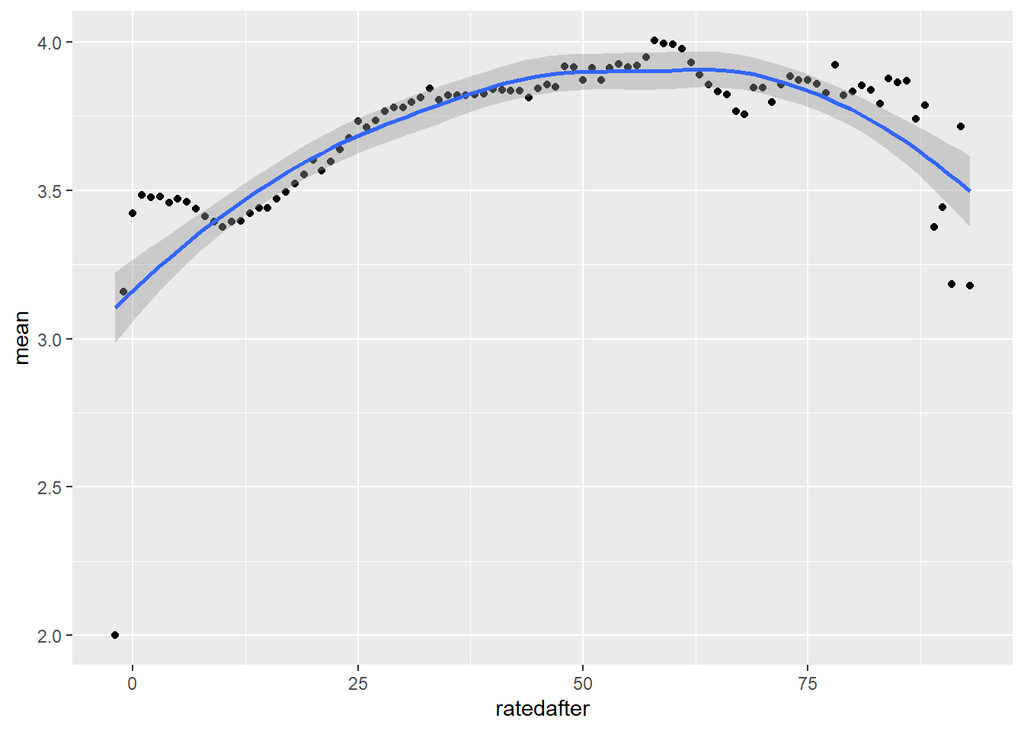

```r
edx%>%group_by(ratedafter)%>%summarise(mean=mean(rating))%>%
  ggplot(aes(ratedafter,mean))+geom_point()+geom_smooth()
```

correlation factor ‘year release’

```r
edx%>%group_by(releaseyear)%>%summarise(mean=mean(rating))%>%
  summarize(cor(mean,as.numeric(releaseyear)))
```

```
## # A tibble: 1 x 1
##   `cor(mean, as.numeric(releaseyear))`
##                                  <dbl>
## 1                               -0.583
```

correlation factor ‘rated year after’

```r
edx%>%group_by(ratedafter)%>%summarise(mean=mean(rating))%>%
  summarize(cor(mean,ratedafter))
```

```
## # A tibble: 1 x 1
##   `cor(mean, ratedafter)`
##                     <dbl>
## 1                   0.487
```

## Validation data set prepration

```r
validation$timestamp=as.POSIXct(validation$timestamp, origin="1970-01-01")
validation$timestamp=format(as.Date(validation$timestamp, format="%d/%m/%Y"),"%Y")

releasev = str_sub(validation$title,start = -5,end = -2)
validation=validation%>%mutate(releaseyear=releasev)
ratedv=as.numeric(validation$timestamp)-as.numeric(validation$releaseyear)
validation=validation%>%mutate(ratedafter=ratedv)

test=validation
validation=validation%>%select(-rating)
```

## RMSE function

```r
RMSE=function(actual,prediction){
  sqrt(mean((actual-prediction)^2,na.rm = T))
}
```

## Simple Model predicting mean

```r
m=mean(edx$rating)
avg_model=RMSE(test$rating,m)
```

Accounting movie effect :

```r
movie=edx%>%group_by(movieId)%>%
  summarise(m_i=mean(rating-m))
```

Accouting user effect :

```r
user=edx%>%
  left_join(movie,by="movieId")%>%
  group_by(userId)%>%
  summarise(u_i=mean(rating-m-m_i))
```

Accounting release year effect :

```r
year=edx%>%
  left_join(movie, by="movieId")%>%
  left_join(user,by="userId")%>%
  group_by(releaseyear)%>%
  summarise(y_i=mean(rating-m-m_i-u_i))
```

Accounting genre effect :

```r
genre=edx%>%
  left_join(movie, by="movieId")%>%
  left_join(user,by="userId")%>%
  left_join(year,by="releaseyear")%>%
  group_by(genres)%>%
  summarise(g_i=mean(rating-m-m_i-u_i-y_i))
```

Accounting years after rated effect :

```r
yearsafter=edx%>%
  left_join(movie, by="movieId")%>%
  left_join(user,by="userId")%>%
  left_join(year,by="releaseyear")%>%
  left_join(genre,by="genres")%>%
  group_by(ratedafter)%>%
  summarise(ya_i=mean(rating-m-m_i-u_i-y_i-g_i))
```

## Model 1: Movie effect

```r
pred_by_m=validation%>%
  left_join(movie,by="movieId")%>%
  mutate(prediction=m+m_i)
model_1=RMSE(test$rating,pred_by_m$prediction)
```

## Model2: Movie & User effect

```r
pred_by_m_u=validation%>%
  left_join(movie,by="movieId")%>%
  left_join(user, by="userId")%>%
  mutate(prediction=m+m_i+u_i)
model_2=RMSE(test$rating,pred_by_m_u$prediction)
```

## Model3: Movie, User and year effect

```r
pred_by_m_u_y=validation%>%
  left_join(movie,by="movieId")%>%
  left_join(user, by="userId")%>%
  left_join(year,by="releaseyear")%>%
  mutate(prediction=m+m_i+u_i+y_i)
model_3=RMSE(test$rating,pred_by_m_u_y$prediction)
```

## Model4: Movie, User, year and genre effect

```r
pred_by_m_u_y_g=validation%>%
  left_join(movie,by="movieId")%>%
  left_join(user, by="userId")%>%
  left_join(year,by="releaseyear")%>%
  left_join(genre,by="genres")%>%
  mutate(prediction=m+m_i+u_i+y_i+g_i)
model_4=RMSE(test$rating,pred_by_m_u_y_g$prediction)
```

## Model5: Movie, User, year, genre and year after rated effect

```r
pred_by_m_u_y_g_ya=validation%>%
  left_join(movie,by="movieId")%>%
  left_join(user, by="userId")%>%
  left_join(year,by="releaseyear")%>%
  left_join(genre,by="genres")%>%
  left_join(yearsafter, by="ratedafter")%>%
  mutate(prediction=m+m_i+u_i+y_i+g_i+ya_i)
model_5=RMSE(test$rating,pred_by_m_u_y_g_ya$prediction)
```

# Regularization

```r
lamdas=seq(0,25,1)
error=sapply(lamdas,function(i){
  m=mean(edx$rating)

  movie=edx%>%group_by(movieId)%>%
    summarise(m_i=sum(rating-m)/(n()+i))


  user=edx%>%
    left_join(movie,by="movieId")%>%
    group_by(userId)%>%
    summarise(u_i=sum(rating-m-m_i)/(n()+i))


  year=edx%>%
    left_join(movie, by="movieId")%>%
    left_join(user,by="userId")%>%
    group_by(releaseyear)%>%
    summarise(y_i=sum(rating-m-m_i-u_i)/(n()+i))


  genre=edx%>%
    left_join(movie, by="movieId")%>%
    left_join(user,by="userId")%>%
    left_join(year,by="releaseyear")%>%
    group_by(genres)%>%
    summarise(g_i=sum(rating-m-m_i-u_i-y_i)/(n()+i))


  yearsafter=edx%>%
    left_join(movie, by="movieId")%>%
    left_join(user,by="userId")%>%
    left_join(year,by="releaseyear")%>%
    left_join(genre,by="genres")%>%
    group_by(ratedafter)%>%
    summarise(ya_i=sum(rating-m-m_i-u_i-y_i-g_i)/(n()))
  pred_regularize=validation%>%
    left_join(movie,by="movieId")%>%
    left_join(user, by="userId")%>%
    left_join(year,by="releaseyear")%>%
    left_join(genre,by="genres")%>%
    left_join(yearsafter, by="ratedafter")%>%
    mutate(prediction=m+m_i+u_i+y_i+g_i+ya_i)
  return(RMSE(test$rating,pred_regularize$prediction))

})
```

Optimal value of lamda

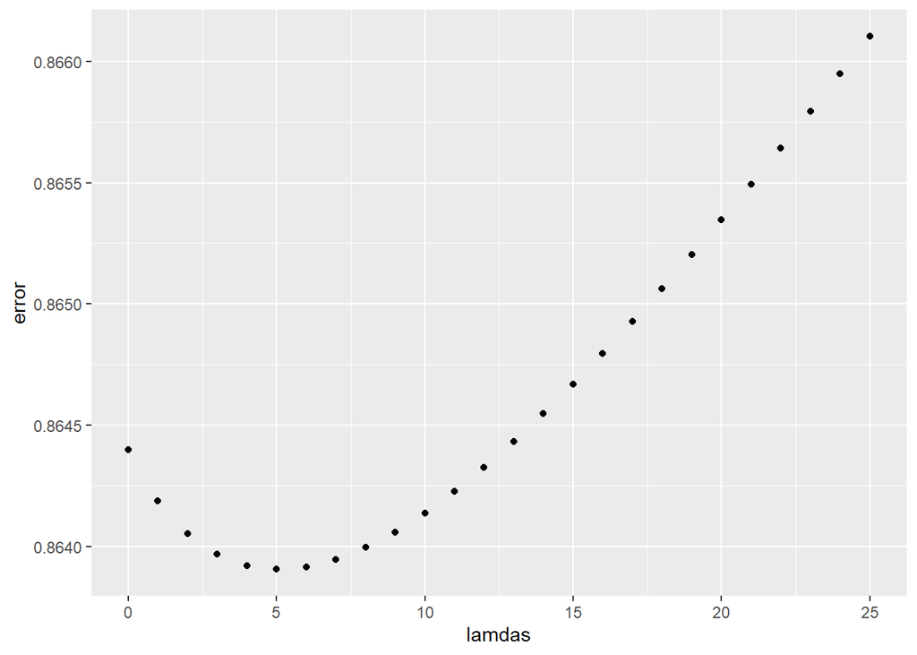

```r
qplot(lamdas,error)
```

```r
l=lamdas[which.min(error)]
```

## Regulariztion model 6

```r
movie=edx%>%group_by(movieId)%>%
  summarise(m_i=sum(rating-m)/(n()+l),n_m=n())
user=edx%>%
  left_join(movie,by="movieId")%>%
  group_by(userId)%>%
  summarise(u_i=sum(rating-m-m_i)/(n()+l),n_u=n())


year=edx%>%
  left_join(movie, by="movieId")%>%
  left_join(user,by="userId")%>%
  group_by(releaseyear)%>%
  summarise(y_i=sum(rating-m-m_i-u_i)/(n()+l),n_y=n())


genre=edx%>%
  left_join(movie, by="movieId")%>%
  left_join(user,by="userId")%>%
  left_join(year,by="releaseyear")%>%
  group_by(genres)%>%
  summarise(g_i=sum(rating-m-m_i-u_i-y_i)/(n()+l),n_g=n())

yearsafter=edx%>%
  left_join(movie, by="movieId")%>%
  left_join(user,by="userId")%>%
  left_join(year,by="releaseyear")%>%
  left_join(genre,by="genres")%>%
  group_by(ratedafter)%>%
  summarise(ya_i=sum(rating-m-m_i-u_i-y_i-g_i)/(n()),n_ya=n())

pred_regularize=validation%>%
  left_join(movie,by="movieId")%>%
  left_join(user, by="userId")%>%
  left_join(year,by="releaseyear")%>%
  left_join(genre,by="genres")%>%
  left_join(yearsafter, by="ratedafter")%>%
  mutate(prediction=m+m_i+u_i+y_i+g_i+ya_i)%>%
  .$prediction
model_6=RMSE(test$rating,pred_regularize)
```

# Model Matrix Factorization using recosystem(LIBMF)

## Data prepration

```r
edx_factor=edx%>%select(movieId,userId,rating)
edx_factor=as.matrix(edx_factor)
write.table(edx_factor,file = "trainset.txt",sep = " ",row.names = FALSE,col.names = FALSE)
trainset=data_file("trainset.txt")
```

Recosystem object creation

```r
r=Reco()
```

## Training

```r
r$train(trainset, opts = list(dim = 30,nthread = 1,niter=20))
```

```
## iter      tr_rmse          obj
##    0       0.9732  1.4989e+007
##    1       0.8803  1.3404e+007
##    2       0.8544  1.3071e+007
##    3       0.8433  1.2955e+007
##    4       0.8348  1.2882e+007
##    5       0.8281  1.2831e+007
##    6       0.8235  1.2791e+007
##    7       0.8197  1.2769e+007
##    8       0.8166  1.2744e+007
##    9       0.8140  1.2726e+007
##   10       0.8121  1.2712e+007
##   11       0.8103  1.2698e+007
##   12       0.8087  1.2693e+007
##   13       0.8073  1.2682e+007
##   14       0.8061  1.2677e+007
##   15       0.8050  1.2670e+007
##   16       0.8040  1.2664e+007
##   17       0.8031  1.2659e+007
##   18       0.8023  1.2658e+007
##   19       0.8015  1.2653e+007
```

```r
stored_prediction = tempfile()
```

## Validation

```r
validation_factor=validation%>%select(movieId,userId)
validation_factor=as.matrix(validation_factor)
write.table(validation_factor,file = "testset.txt",sep = " ",row.names = FALSE,col.names = FALSE)
testset=data_file("testset.txt")
r$predict(testset,out_file(stored_prediction))
```

```
## prediction output generated at C:\Users\ADMINI~1\AppData\Local\Temp\RtmpEfnu42\file1ae82742183e
```

```r
prediction=scan(stored_prediction)
```

# RMSE

```r
recosystem_model=RMSE(test$rating,prediction)
```

# All model Summary

```r
recosystem_model=RMSE(test$rating,prediction)
all_model=data.frame(modelname=c("Simple Model","movie","movie_user","movie_user_year","movie_user_year_genre","movie_user_year_genre_ratedafter","Regularization","Recosystem"),modelperf=c(avg_model,model_1,model_2,model_3,model_4,model_5,model_6,recosystem_model))
all_model
```

```
##                          modelname modelperf
## 1                     Simple Model 1.0612018
## 2                            movie 0.9439087
## 3                       movie_user 0.8653488
## 4                  movie_user_year 0.8650043
## 5            movie_user_year_genre 0.8647135
## 6 movie_user_year_genre_ratedafter 0.8643998
## 7                   Regularization 0.8639053
## 8                       Recosystem 0.8183729
```